# R Notebook

Ousam Salah

### Case Study

This R notebook is aiming to answer business tasks and deliver useful insights and high recommendations to reveal more opportunities for growth.

### Business Plan

Bellabeat, a high-tech company that manufactures health-focused smart products. Our objective is to analyze smart devices usage data in order to gain insight about how consumers use Bellabeat products, and how theses insights can identify potential opportunities for growth and recommendations for the Bellabeat marketing strategy improvement.

- What are some trends in smart device usage ?
- How could these trends apply to Bellabeat customers ?
- How could these trends help influence Bellabeat marketing strategy ?

After we identified the business task , we should now prepare and load the data needed for the analysis , **the data we are going to use is an open dataset from kaggle which can be found [here](https://www.kaggle.com/datasets/arashnic/fitbit)**. the data source contains many different CSV files, we are going choose a certain files to work with.

```r
##load libraries
library(tidyverse)
```

```r
library(dplyr)
library(ggplot2)
library(lubridate)
```

The analysis will focus on daily inputs as it is better for discovering health benefits trends.

```r
# Import all all relevant csv files as R data frames
dailyActivity <- read_csv("Fitabase Data 4.12.16-5.12.16/dailyActivity_merged.csv")
dailySleep <- read_csv("Fitabase Data 4.12.16-5.12.16/sleepDay_merged.csv")
weightInfo <- read_csv("Fitabase Data 4.12.16-5.12.16/weightLogInfo_merged.csv")
# Preview the data frames
head(dailyActivity)
```

| Id | ActivityDate | TotalSteps | TotalDistance | TrackerDistance | LoggedActivitiesDistance | VeryActiveDistance | ModeratelyActiveDistance | LightActiveDistance | SedentaryActiveDistance | VeryActiveMinutes | FairlyActiveMinutes | LightlyActiveMinutes | SedentaryMinutes | Calories |
| --- | --- | --- | --- | --- | --- | --- | --- | --- | --- | --- | --- | --- | --- | --- |
| 1503960366 | 4/12/2016 | 13162 | 8.50 | 8.50 | 0 | 1.88 | 0.55 | 6.06 | 0 | 25 | 13 | 328 | 728 | 1985 |
| 1503960366 | 4/13/2016 | 10735 | 6.97 | 6.97 | 0 | 1.57 | 0.69 | 4.71 | 0 | 21 | 19 | 217 | 776 | 1797 |
| 1503960366 | 4/14/2016 | 10460 | 6.74 | 6.74 | 0 | 2.44 | 0.40 | 3.91 | 0 | 30 | 11 | 181 | 1218 | 1776 |
| 1503960366 | 4/15/2016 | 9762 | 6.28 | 6.28 | 0 | 2.14 | 1.26 | 2.83 | 0 | 29 | 34 | 209 | 726 | 1745 |
| 1503960366 | 4/16/2016 | 12669 | 8.16 | 8.16 | 0 | 2.71 | 0.41 | 5.04 | 0 | 36 | 10 | 221 | 773 | 1863 |
| 1503960366 | 4/17/2016 | 9705 | 6.48 | 6.48 | 0 | 3.19 | 0.78 | 2.51 | 0 | 38 | 20 | 164 | 539 | 1728 |

```r
head(dailySleep)
```

| Id | SleepDay | TotalSleepRecords | TotalMinutesAsleep | TotalTimeInBed |
| --- | --- | --- | --- | --- |
| 1503960366 | 4/12/2016 12:00:00 AM | 1 | 327 | 346 |
| 1503960366 | 4/13/2016 12:00:00 AM | 2 | 384 | 407 |
| 1503960366 | 4/15/2016 12:00:00 AM | 1 | 412 | 442 |
| 1503960366 | 4/16/2016 12:00:00 AM | 2 | 340 | 367 |
| 1503960366 | 4/17/2016 12:00:00 AM | 1 | 700 | 712 |
| 1503960366 | 4/19/2016 12:00:00 AM | 1 | 304 | 320 |

```r
head(weightInfo)
```

| Id | Date | WeightKg | WeightPounds | Fat | BMI | IsManualReport | LogId |
| --- | --- | --- | --- | --- | --- | --- | --- |
| 1503960366 | 5/2/2016 11:59:59 PM | 52.6 | 115.9631 | 22 | 22.65 | TRUE | 1.462234e+12 |
| 1503960366 | 5/3/2016 11:59:59 PM | 52.6 | 115.9631 | NA | 22.65 | TRUE | 1.462320e+12 |
| 1927972279 | 4/13/2016 1:08:52 AM | 133.5 | 294.3171 | NA | 47.54 | FALSE | 1.460510e+12 |
| 2873212765 | 4/21/2016 11:59:59 PM | 56.7 | 125.0021 | NA | 21.45 | TRUE | 1.461283e+12 |
| 2873212765 | 5/12/2016 11:59:59 PM | 57.3 | 126.3249 | NA | 21.69 | TRUE | 1.463098e+12 |
| 4319703577 | 4/17/2016 11:59:59 PM | 72.4 | 159.6147 | 25 | 27.45 | TRUE | 1.460938e+12 |

All three data frames need some formatting to be usable and can be merged with the Id and Date keys.

```r
# Cleaning and transforming the datas

#dailyActivity dataset
dailyActivity <- dailyActivity %>%
  rename(Date = ActivityDate) %>%
  mutate(Date = as.Date(Date, format = "%m/%d/%y"))

#dailySleep dataset
dailySleep <- dailySleep %>%
  rename(Date = SleepDay) %>%
  mutate(Date = as.Date(Date, format = "%m/%d/%y"))

#weightInfo dataset
weightInfo <- weightInfo %>%
  select(-LogId) %>%
  mutate(Date = as.Date(Date, format = "%m/%d/%y")) %>%
  mutate(IsManualReport = as.factor(IsManualReport))
```

```r
#Merging all datas into one dataframe to simplify analysis

fitInfo <- merge(dailyActivity, dailySleep, by = c('Id', 'Date'), all = TRUE)
fitInfo <- merge(fitInfo, weightInfo, by = c('Id','Date'), all = TRUE)
head(fitInfo)
```

|  | Id | Date | TotalSteps | TotalDistance | TrackerDistance | LoggedActivitiesDistance | VeryActiveDistance | ModeratelyActiveDistance | LightActiveDistance | SedentaryActiveDistance | VeryActiveMinutes | FairlyActiveMinutes | LightlyActiveMinutes | SedentaryMinutes | Calories | TotalSleepRecords | TotalMinutesAsleep | TotalTimeInBed | WeightKg | WeightPounds | Fat | BMI | IsManualReport |
| --- | --- | --- | --- | --- | --- | --- | --- | --- | --- | --- | --- | --- | --- | --- | --- | --- | --- | --- | --- | --- | --- | --- | --- |
| 1 | 1503960366 | 2020-04-12 | 13162 | 8.50 | 8.50 | 0 | 1.88 | 0.55 | 6.06 | 0 | 25 | 13 | 328 | 728 | 1985 | 1 | 327 | 346 | NA | NA | NA | NA | NA |
| 2 | 1503960366 | 2020-04-13 | 10735 | 6.97 | 6.97 | 0 | 1.57 | 0.69 | 4.71 | 0 | 21 | 19 | 217 | 776 | 1797 | 2 | 384 | 407 | NA | NA | NA | NA | NA |
| 3 | 1503960366 | 2020-04-14 | 10460 | 6.74 | 6.74 | 0 | 2.44 | 0.40 | 3.91 | 0 | 30 | 11 | 181 | 1218 | 1776 | NA | NA | NA | NA | NA | NA | NA | NA |
| 4 | 1503960366 | 2020-04-15 | 9762 | 6.28 | 6.28 | 0 | 2.14 | 1.26 | 2.83 | 0 | 29 | 34 | 209 | 726 | 1745 | 1 | 412 | 442 | NA | NA | NA | NA | NA |
| 5 | 1503960366 | 2020-04-16 | 12669 | 8.16 | 8.16 | 0 | 2.71 | 0.41 | 5.04 | 0 | 36 | 10 | 221 | 773 | 1863 | 2 | 340 | 367 | NA | NA | NA | NA | NA |
| 6 | 1503960366 | 2020-04-17 | 9705 | 6.48 | 6.48 | 0 | 3.19 | 0.78 | 2.51 | 0 | 38 | 20 | 164 | 539 | 1728 | 1 | 700 | 712 | NA | NA | NA | NA | NA |

```r
# Let's determine the percentage of empty observation by variable
(colMeans(is.na(fitInfo)))*100
```

```
##                       Id                     Date               TotalSteps
##                  0.00000                  0.00000                  0.00000
##            TotalDistance          TrackerDistance LoggedActivitiesDistance
##                  0.00000                  0.00000                  0.00000
##       VeryActiveDistance ModeratelyActiveDistance      LightActiveDistance
##                  0.00000                  0.00000                  0.00000
##  SedentaryActiveDistance        VeryActiveMinutes      FairlyActiveMinutes
##                  0.00000                  0.00000                  0.00000
##     LightlyActiveMinutes         SedentaryMinutes                 Calories
##                  0.00000                  0.00000                  0.00000
##        TotalSleepRecords       TotalMinutesAsleep           TotalTimeInBed
##                 56.20361                 56.20361                 56.20361
##                 WeightKg             WeightPounds                      Fat
##                 92.89502                 92.89502                 99.78791
##                      BMI           IsManualReport
##                 92.89502                 92.89502
```

We can see that BMI, Manual Report, Fat Weights have more than 90% NA values. There is also duplicate columns so we can remove them from the data frame.

```r
fitInfo <- fitInfo %>% select(-c(TrackerDistance, LoggedActivitiesDistance, TotalSleepRecords, WeightPounds, WeightKg, Fat, BMI, IsManualReport))
```

Lets have a summary of the data frame

```r
str(fitInfo)
```

```
## 'data.frame':    943 obs. of  15 variables:
##  $ Id                      : num  1.5e+09 1.5e+09 1.5e+09 1.5e+09 1.5e+09 ...
##  $ Date                    : Date, format: "2020-04-12" "2020-04-13" ...
##  $ TotalSteps              : num  13162 10735 10460 9762 12669 ...
##  $ TotalDistance           : num  8.5 6.97 6.74 6.28 8.16 ...
##  $ VeryActiveDistance      : num  1.88 1.57 2.44 2.14 2.71 ...
##  $ ModeratelyActiveDistance: num  0.55 0.69 0.4 1.26 0.41 ...
##  $ LightActiveDistance     : num  6.06 4.71 3.91 2.83 5.04 ...
##  $ SedentaryActiveDistance : num  0 0 0 0 0 0 0 0 0 0 ...
##  $ VeryActiveMinutes       : num  25 21 30 29 36 38 42 50 28 19 ...
##  $ FairlyActiveMinutes     : num  13 19 11 34 10 20 16 31 12 8 ...
##  $ LightlyActiveMinutes    : num  328 217 181 209 221 164 233 264 205 211 ...
##  $ SedentaryMinutes        : num  728 776 1218 726 773 ...
##  $ Calories                : num  1985 1797 1776 1745 1863 ...
##  $ TotalMinutesAsleep      : num  327 384 NA 412 340 700 NA 304 360 325 ...
##  $ TotalTimeInBed          : num  346 407 NA 442 367 712 NA 320 377 364 ...
```

```r
# explore numerical varialbes per category
fitInfo %>%
  select(-c(Id,Date))%>%
  summary()
```

```
##    TotalSteps    TotalDistance    VeryActiveDistance ModeratelyActiveDistance
##  Min.   :    0   Min.   : 0.000   Min.   : 0.000     Min.   :0.0000
##  1st Qu.: 3795   1st Qu.: 2.620   1st Qu.: 0.000     1st Qu.:0.0000
##  Median : 7439   Median : 5.260   Median : 0.220     Median :0.2400
##  Mean   : 7652   Mean   : 5.503   Mean   : 1.504     Mean   :0.5709
##  3rd Qu.:10734   3rd Qu.: 7.720   3rd Qu.: 2.065     3rd Qu.:0.8050
##  Max.   :36019   Max.   :28.030   Max.   :21.920     Max.   :6.4800
##
##  LightActiveDistance SedentaryActiveDistance VeryActiveMinutes
##  Min.   : 0.000      Min.   :0.000000        Min.   :  0.00
##  1st Qu.: 1.950      1st Qu.:0.000000        1st Qu.:  0.00
##  Median : 3.380      Median :0.000000        Median :  4.00
##  Mean   : 3.349      Mean   :0.001601        Mean   : 21.24
##  3rd Qu.: 4.790      3rd Qu.:0.000000        3rd Qu.: 32.00
##  Max.   :10.710      Max.   :0.110000        Max.   :210.00
##
##  FairlyActiveMinutes LightlyActiveMinutes SedentaryMinutes    Calories
##  Min.   :  0.00      Min.   :  0          Min.   :   0.0   Min.   :   0
##  1st Qu.:  0.00      1st Qu.:127          1st Qu.: 729.0   1st Qu.:1830
##  Median :  7.00      Median :199          Median :1057.0   Median :2140
##  Mean   : 13.63      Mean   :193          Mean   : 990.4   Mean   :2308
##  3rd Qu.: 19.00      3rd Qu.:264          3rd Qu.:1229.0   3rd Qu.:2796
##  Max.   :143.00      Max.   :518          Max.   :1440.0   Max.   :4900
##
##  TotalMinutesAsleep TotalTimeInBed
##  Min.   : 58.0      Min.   : 61.0
##  1st Qu.:361.0      1st Qu.:403.0
##  Median :433.0      Median :463.0
##  Mean   :419.5      Mean   :458.6
##  3rd Qu.:490.0      3rd Qu.:526.0
##  Max.   :796.0      Max.   :961.0
##  NA's   :530        NA's   :530
```

**Insights from this snapshot:**

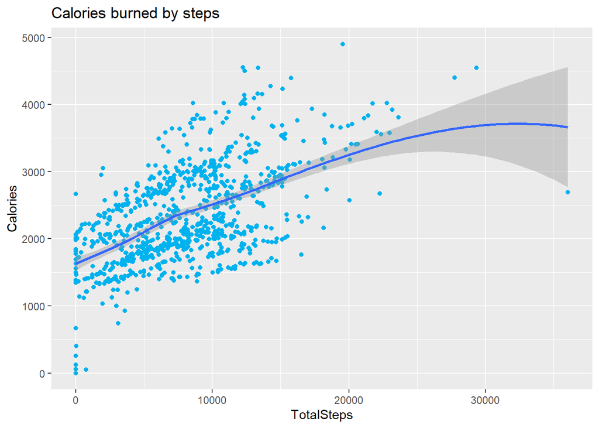

```r
# Create a scater plot of totals steps and calories for all users
ggplot(data=fitInfo, aes(x=TotalSteps, y=Calories)) +
  geom_point(color='deepskyblue2') +
  geom_smooth() +
  labs(title="Calories burned by steps")
```

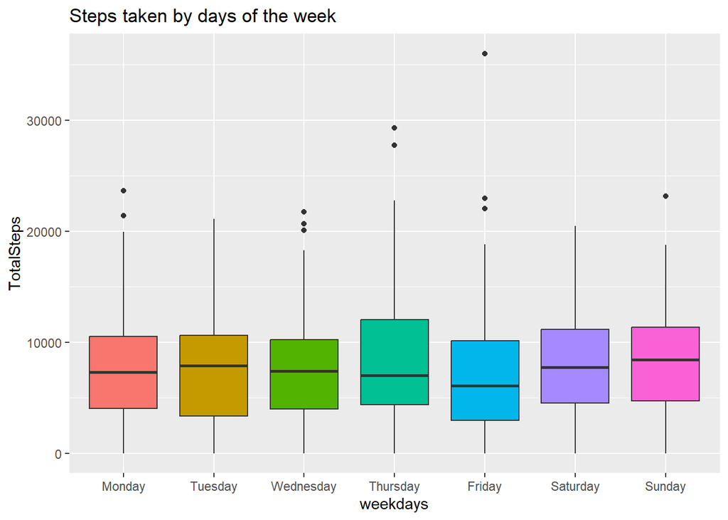

```r
#Box plots of the steps taken by users each day of the study
fitInfo %>%
  mutate(weekdays = weekdays(Date)) %>%
  select(weekdays, TotalSteps) %>%
  mutate(weekdays = factor(weekdays, levels = c('Monday', 'Tuesday', 'Wednesday', 'Thursday', 'Friday', 'Saturday', 'Sunday'))) %>%
  drop_na() %>%
  ggplot(aes(weekdays, TotalSteps, fill = weekdays)) +
  geom_boxplot()+
  labs(title = "Steps taken by days of the week")+
  theme(legend.position="none")
```

There is not any particular trend appearing as average total steps stays between (5 000-10 000) expect for some outliers between Wednesday and Friday, meaning that days of the week are not factors of activity.

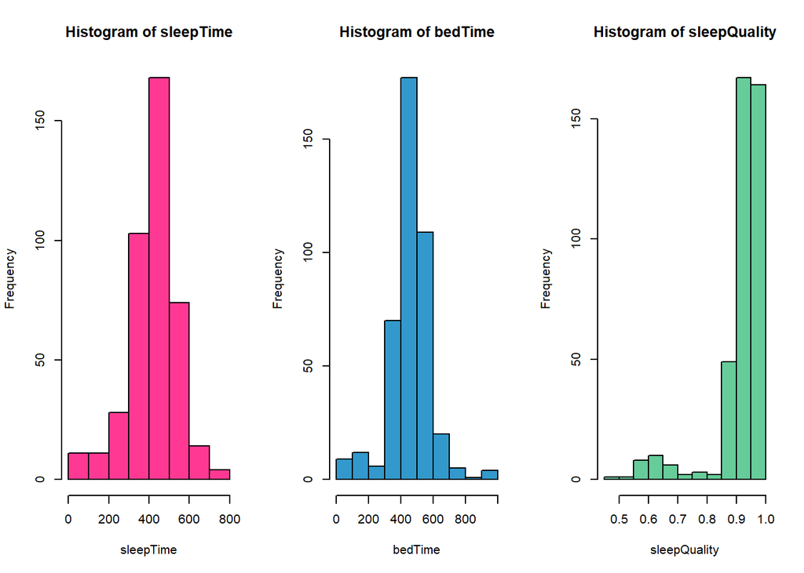

```r
#plotting threes graphs to check sleeps in users
sleepTime <- fitInfo$TotalMinutesAsleep
bedTime <- fitInfo$TotalTimeInBed
par(mfrow=c(1,3))
hist(sleepTime, col = "#ff3993")
hist(bedTime, col = "#3399cc")
sleepQuality = sleepTime/bedTime
hist(sleepQuality, col = "#66CC99")
```

We can see that most of the sample have good sleep to time in bed ration meaning they don’t have insomnia. Let’s some factors that can explain why.

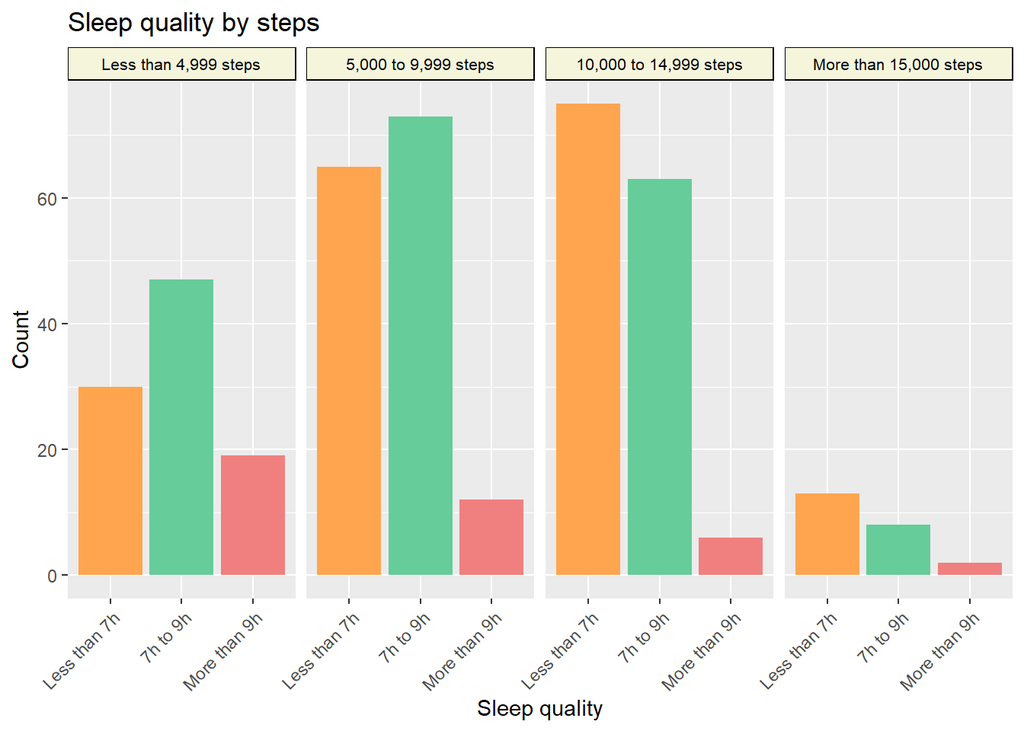

```r
fitInfo %>%
  select(TotalMinutesAsleep, TotalSteps) %>%
  mutate(sleep_quality = ifelse(TotalMinutesAsleep <= 420, 'Less than 7h',
                                ifelse(TotalMinutesAsleep <= 540, '7h to 9h',
                                       'More than 9h'))) %>%
  mutate(active_level = ifelse(TotalSteps >= 15000,'More than 15,000 steps',
                               ifelse(TotalSteps >= 10000,'10,000 to 14,999 steps',
                                      ifelse(TotalSteps >= 5000, '5,000 to 9,999 steps',
                                             'Less than 4,999 steps')))) %>%
  select(-c(TotalMinutesAsleep, TotalSteps)) %>%
  drop_na() %>%
  group_by(sleep_quality, active_level) %>%
  summarise(counts = n()) %>%
  mutate(active_level = factor(active_level,
                               levels = c('Less than 4,999 steps',
                                          '5,000 to 9,999 steps',
                                          '10,000 to 14,999 steps',
                                          'More than 15,000 steps'))) %>%
  mutate(sleep_quality = factor(sleep_quality,
                                levels = c('Less than 7h','7h to 9h',
                                           'More than 9h'))) %>%
  ggplot(aes(x = sleep_quality,
             y = counts,
             fill = sleep_quality)) +
  geom_bar(stat = "identity") +
  scale_fill_manual(values=c("tan1", "#66CC99", "lightcoral")) +
  facet_wrap(~active_level, nrow = 1) +
  theme(legend.position = "none") +
  theme(axis.text.x = element_text(angle = 45, hjust = 1)) +
  theme(strip.text = element_text(colour = 'black', size = 8)) +
  theme(strip.background = element_rect(fill = "beige", color = 'black'))+
  labs(
    title = "Sleep quality by steps",
    x = "Sleep quality",
    y = "Count"
  )
```

We can see that the sample with the best sleep time quality take [5000 - 10000] steps per day.

### Summarizing recommendations for the business

- Calories are burnt by the steps taken daily. Based on users objectives, Bellabeat could recommend a minimum number of steps for users to take to encourage them to achieve their goals.
- In order to create a habit of exercising every day, Bellabeat could send a notification at a specific time for the user to remain consistent throughout the week.
- The data shows that in order to sleep better the best type of exercise is light to moderate (less than 10,000 steps). Bellabeat could recommend this level of exercise for people who want to simply maintain a healthy lifestyle.